# Data 607 – Final Project

Student_Name: Pravalika Sure  
UID: 120558016

## State-Level Drivers of COVID-19 Mortality in the United States (2021)

### 1.1 Loading required packages

```r
# Load required packages

library(COVID19)
library(dplyr)
```

```r
library(ggplot2)
library(lubridate)
library(janitor)
library(pROC)
library(corrplot)
library(zoo)
library(usmap)
library(randomForest)
library(car)       # for VIF
```

## 2.Data Loading and Initial Cleaning

**Exploring entire dataset**

```r
# Load global COVID-19 data at level 2 (states/provinces)
raw_df <- covid19(level = 2)
```

[output not shown]

```r
# Basic structure
glimpse(raw_df)
```

```
## Rows: 862,520
## Columns: 47
## $ id                                  <chr> "0042529a", "0042529a", "0042529a"…
## $ date                                <date> 2020-01-12, 2020-01-13, 2020-01-1…
## $ confirmed                           <int> 0, 0, 0, 0, 0, 0, 0, 0, 0, 0, 0, 0…
## $ deaths                              <int> 0, 0, 0, 0, 0, 0, 0, 0, 0, 0, 0, 0…
## $ recovered                           <int> NA, NA, NA, NA, NA, NA, NA, NA, NA…
## $ tests                               <int> NA, NA, NA, NA, NA, NA, NA, NA, NA…
## $ vaccines                            <int> NA, NA, NA, NA, NA, NA, NA, NA, NA…
## $ people_vaccinated                   <int> NA, NA, NA, NA, NA, NA, NA, NA, NA…
## $ people_fully_vaccinated             <int> NA, NA, NA, NA, NA, NA, NA, NA, NA…
## $ hosp                                <int> NA, NA, NA, NA, NA, NA, NA, NA, NA…
## $ icu                                 <int> NA, NA, NA, NA, NA, NA, NA, NA, NA…
## $ vent                                <int> NA, NA, NA, NA, NA, NA, NA, NA, NA…
## $ school_closing                      <int> 0, 0, 0, 0, 0, 0, 0, 0, 0, 0, 0, 0…
```

[output cut: 34 more lines]

**Filtering out USA Data**

```r
df <- covid19(level = 2) %>% clean_names()
```

[output not shown]

```r
usa <- df %>%
  filter(administrative_area_level_1 == "United States") %>%
  rename(state = administrative_area_level_2)
```

**Checking for the filtered data**

```r
unique(usa$state)
```

```
##  [1] "Northern Mariana Islands" "Minnesota"
##  [3] "California"               "Florida"
##  [5] "Wyoming"                  "Virgin Islands"
##  [7] "South Dakota"             "Kansas"
##  [9] "Nevada"                   "Virginia"
## [11] "Washington"               "Oregon"
## [13] "Wisconsin"                "New Jersey"
## [15] "Rhode Island"             "Vermont"
## [17] "North Carolina"           "Oklahoma"
## [19] "Alabama"                  "Delaware"
## [21] "Guam"                     "Missouri"
## [23] "American Samoa"           "Utah"
## [25] "Mississippi"              "Connecticut"
## [27] "Indiana"                  "Georgia"
## [29] "Texas"                    "Pennsylvania"
## [31] "Massachusetts"            "Maine"
## [33] "Tennessee"                "Michigan"
## [35] "Idaho"                    "Illinois"
## [37] "Louisiana"                "New Mexico"
## [39] "Arizona"                  "Arkansas"
## [41] "Nebraska"                 "West Virginia"
## [43] "South Carolina"           "New York"
## [45] "District of Columbia"     "Kentucky"
## [47] "Ohio"                     "Alaska"
## [49] "New Hampshire"            "North Dakota"
## [51] "Iowa"                     "Montana"
## [53] "Hawaii"                   "Maryland"
## [55] "Puerto Rico"              "Colorado"
```

```r
usa_2021 <- usa %>%
  filter(date >= "2021-01-01", date <= "2021-12-31")
```

## 3. Feature Engineering and Handling Missing Data

### 3.1.Handling missing values

```r
# Check which vaccine variable exists
grep("vacc", names(usa_2021), value = TRUE)
```

```
## [1] "vaccines"                "people_vaccinated"
## [3] "people_fully_vaccinated" "vaccination_policy"
```

```r
state_summ <- usa_2021 %>%
  group_by(state) %>%
  summarise(
    population        = max(population, na.rm = TRUE),
    total_deaths      = max(deaths, na.rm = TRUE),
    deaths_per_100k   = (total_deaths / population) * 100000,
    total_tests       = max(tests, na.rm = TRUE),
    tests_per_1k      = (total_tests / population) * 1000,
    vax_coverage      = max(people_fully_vaccinated, na.rm = TRUE) / population,
    mean_stringency   = mean(stringency_index, na.rm = TRUE)
  )
```

### 3.2. CLEANING: Replace -Inf/Inf with NA + Filter NAs

```r
state_clean <- state_summ %>%
  mutate(
    total_tests       = ifelse(is.infinite(total_tests), NA, total_tests),
    tests_per_1k      = ifelse(is.infinite(tests_per_1k), NA, tests_per_1k),
    vax_coverage      = ifelse(is.infinite(vax_coverage), NA, vax_coverage),
    deaths_per_100k   = ifelse(is.infinite(deaths_per_100k), NA, deaths_per_100k),
    mean_stringency   = ifelse(is.infinite(mean_stringency), NA, mean_stringency)
  ) %>%
  filter(
    !is.na(deaths_per_100k),
    !is.na(vax_coverage),
    !is.na(tests_per_1k),
    !is.na(mean_stringency)
  )

glimpse(state_clean)
```

```
## Rows: 51
## Columns: 8
## $ state           <chr> "Alabama", "Alaska", "Arizona", "Arkansas", "Californi…
## $ population      <int> 4903185, 731545, 7278717, 3017804, 39512223, 5758736, …
## $ total_deaths    <int> 16455, 954, 24229, 9148, 76709, 10480, 9161, 2286, 121…
## $ deaths_per_100k <dbl> 335.59819, 130.40893, 332.87460, 303.13433, 194.13992,…
## $ total_tests     <dbl> 6647224, 3747402, 12531573, 4084594, 106951711, 130160…
## $ tests_per_1k    <dbl> 1355.6951, 5122.5858, 1721.6733, 1353.4988, 2706.8007,…
## $ vax_coverage    <dbl> 0.4908059, 0.6110232, 0.6024869, 0.5245245, 0.6808680,…
## $ mean_stringency <dbl> 35.44597, 44.82907, 35.58422, 39.22830, 49.78534, 43.2…
```

### 3.3. Handle infinite and missing values and remove rows with critical missingness

```r
state_clean <- state_summ %>%
  mutate(
    vax_coverage = ifelse(is.infinite(vax_coverage), NA, vax_coverage),
    tests_per_1k = ifelse(is.infinite(tests_per_1k), NA, tests_per_1k)
  ) %>%
  filter(
    !is.na(deaths_per_100k),
    !is.na(vax_coverage),
    !is.na(tests_per_1k),
    !is.na(mean_stringency),
    !is.na(population)
  )
```

Some US territories (American Samoa, Guam, Northern Mariana Islands, etc.) reported no testing or vaccination data in 2021, causing max() to return -Inf. To avoid distortions, I replaced all ±Inf values with NA and filtered out states/territories missing key predictors (vaccination, testing, stringency, or death rates). This preserves the integrity of the dataset while retaining as many states as possible for multivariate analysis.

### 3.4. Remove extreme outliers in deaths_per_100k using IQR rule

```r
q1 <- quantile(state_clean$deaths_per_100k, 0.25)
q3 <- quantile(state_clean$deaths_per_100k, 0.75)
iqr <- q3 - q1
upper_cut <- q3 + 1.5 * iqr

state_clean <- state_clean %>%
  filter(deaths_per_100k <= upper_cut)

glimpse(state_clean)
```

```
## Rows: 51
## Columns: 8
## $ state           <chr> "Alabama", "Alaska", "Arizona", "Arkansas", "Californi…
## $ population      <int> 4903185, 731545, 7278717, 3017804, 39512223, 5758736, …
## $ total_deaths    <int> 16455, 954, 24229, 9148, 76709, 10480, 9161, 2286, 121…
## $ deaths_per_100k <dbl> 335.59819, 130.40893, 332.87460, 303.13433, 194.13992,…
## $ total_tests     <dbl> 6647224, 3747402, 12531573, 4084594, 106951711, 130160…
## $ tests_per_1k    <dbl> 1355.6951, 5122.5858, 1721.6733, 1353.4988, 2706.8007,…
## $ vax_coverage    <dbl> 0.4908059, 0.6110232, 0.6024869, 0.5245245, 0.6808680,…
## $ mean_stringency <dbl> 35.44597, 44.82907, 35.58422, 39.22830, 49.78534, 43.2…
```

## 4. Exploratory Data Analysis (EDA)

### 4.1 Distribution of Death Rates

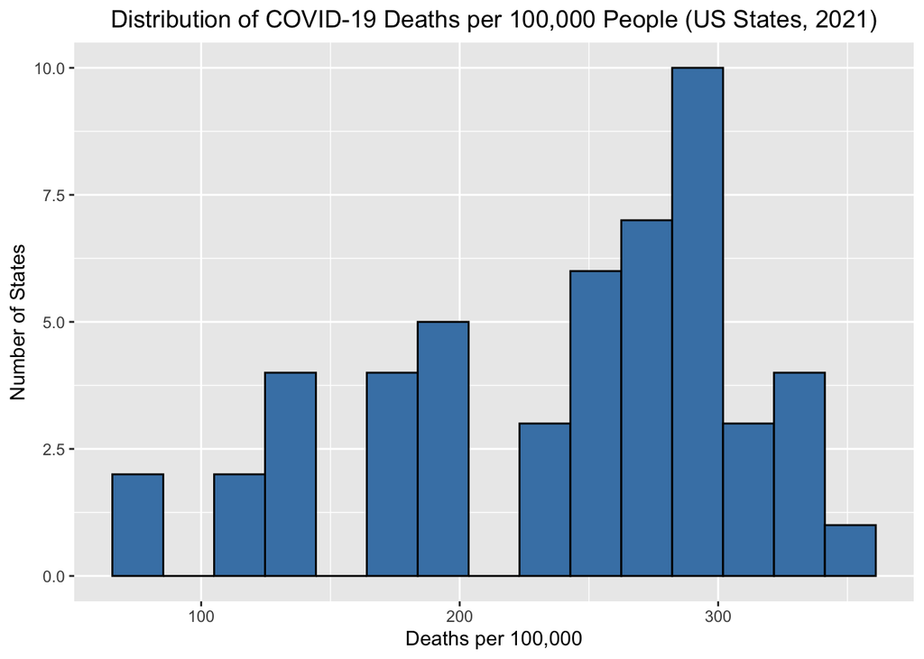

```r
ggplot(state_clean, aes(x = deaths_per_100k)) +
  geom_histogram(bins = 15, fill = "steelblue", color = "black") +
  labs(
    title = "Distribution of COVID-19 Deaths per 100,000 People (US States, 2021)",
    x = "Deaths per 100,000",
    y = "Number of States"
  ) +
  theme(plot.title = element_text(hjust = 0.5))
```

### 4.2 Scatterplots: Vaccination, Testing, and Stringency vs Mortality

**Vaccination vs COVID-19 Deaths per 100k**

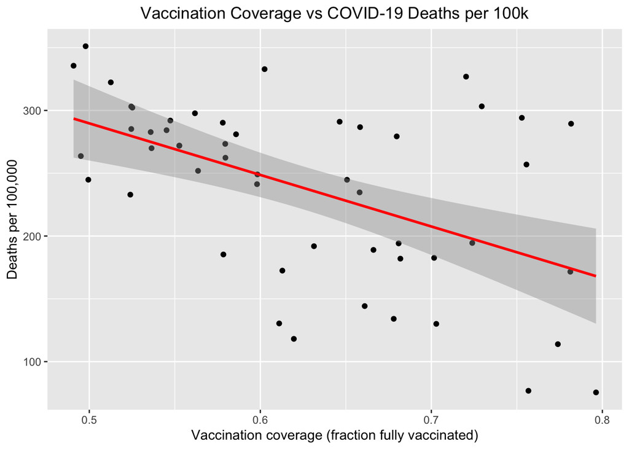

```r
ggplot(state_clean, aes(x = vax_coverage, y = deaths_per_100k)) +
  geom_point() +
  geom_smooth(method = "lm", se = TRUE, color = "red") +
  labs(
    title = "Vaccination Coverage vs COVID-19 Deaths per 100k",
    x = "Vaccination coverage (fraction fully vaccinated)",
    y = "Deaths per 100,000"
  ) +
  theme(plot.title = element_text(hjust = 0.5))
```

**Interpretation:**

The plot shows a clear negative relationship between vaccination coverage and COVID-19 death rates. States with higher fractions of fully vaccinated residents generally experienced fewer deaths per 100,000. While there is some variation across states, the downward trend indicates that increased vaccination is strongly associated with lower mortality.

**Testing Intensity vs COVID-19 Deaths per 100k**

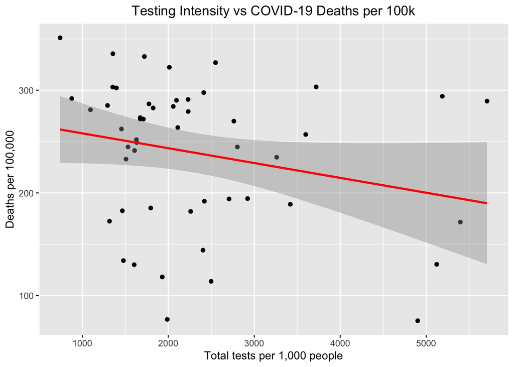

```r
ggplot(state_clean, aes(x = tests_per_1k, y = deaths_per_100k)) +
  geom_point() +
  geom_smooth(method = "lm", se = TRUE, color = "red") +
  labs(
    title = "Testing Intensity vs COVID-19 Deaths per 100k",
    x = "Total tests per 1,000 people",
    y = "Deaths per 100,000"
  )+
  theme(plot.title = element_text(hjust = 0.5))
```

**Interpretation:**

The downward-sloping regression line suggests a weak negative relationship between testing intensity and COVID-19 death rates. States that conducted more tests per 1,000 people tended to have slightly lower mortality, but the points are widely scattered. This indicates that testing alone does not strongly predict death rates, and other factors—such as vaccination coverage or demographics—likely play a larger role.

**Policy Stringency vs COVID-19 Deaths per 100k**

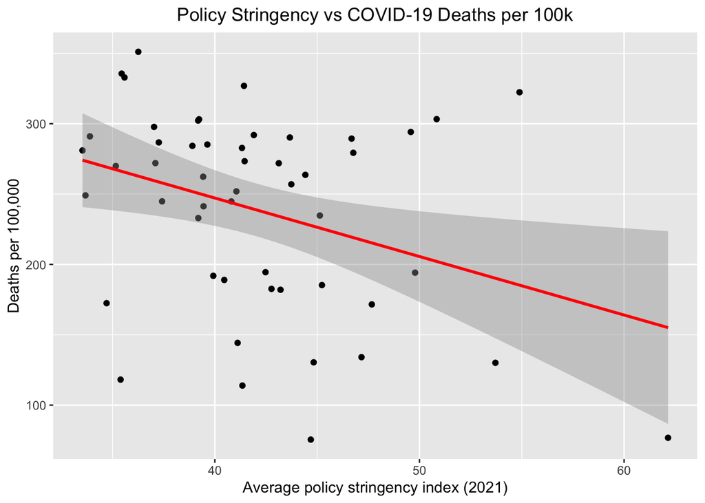

```r
ggplot(state_clean, aes(x = mean_stringency, y = deaths_per_100k)) +
  geom_point() +
  geom_smooth(method = "lm", se = TRUE, color = "red") +
  labs(
    title = "Policy Stringency vs COVID-19 Deaths per 100k",
    x = "Average policy stringency index (2021)",
    y = "Deaths per 100,000"
  )+
  theme(plot.title = element_text(hjust = 0.5))
```

**Interpretation:**

This plot shows a moderate negative relationship between policy stringency and COVID-19 deaths per 100,000 people across US states in 2021. States with stricter average policies tended to have lower mortality, as indicated by the downward-sloping regression line. While there is noticeable variability across states (shown by the wide confidence band), the overall trend suggests that stronger public-health measures were generally associated with fewer deaths, though policy stringency alone does not fully explain state-level differences.

## 5. Correlation Analysis

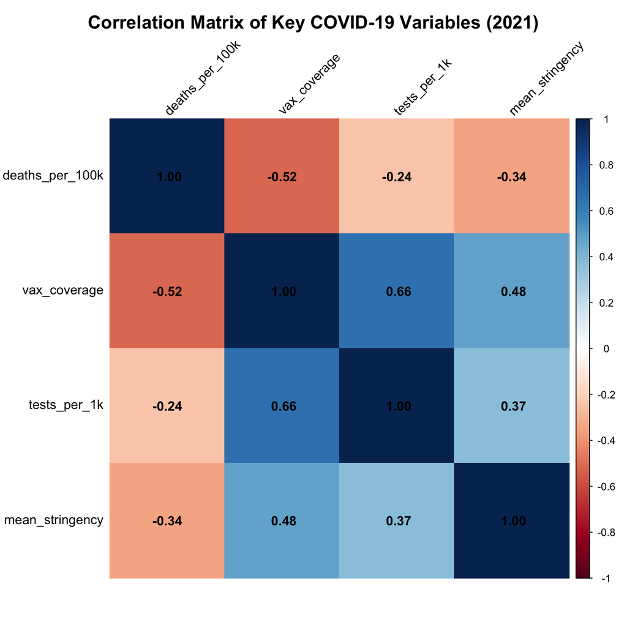

```r
num_vars <- state_clean %>%
  select(deaths_per_100k, vax_coverage, tests_per_1k, mean_stringency)

cor_matrix <- cor(num_vars, use = "complete.obs")

par(mar = c(4, 4, 12, 4))

corrplot(
  cor_matrix,
  method = "color",
  addCoef.col = "black",
  tl.col = "black",
  tl.srt = 45
)

mtext("Correlation Matrix of Key COVID-19 Variables (2021)",
      side = 3, line = 10, cex = 1.4, font = 2, adj = 0.5)
```

## 6. Regression Modeling: Explaining Mortality

### 6.1 Baseline Linear Regression Model

```r
lm_fit <- lm(
  deaths_per_100k ~ vax_coverage + tests_per_1k + mean_stringency,
  data = state_clean
)

summary(lm_fit)
```

```
##
## Call:
## lm(formula = deaths_per_100k ~ vax_coverage + tests_per_1k +
##     mean_stringency, data = state_clean)
##
## Residuals:
##      Min       1Q   Median       3Q      Max
## -140.286  -45.239    6.425   34.984  128.379
##
## Coefficients:
##                   Estimate Std. Error t value Pr(>|t|)
## (Intercept)      5.679e+02  7.962e+01   7.133 5.14e-09 ***
## vax_coverage    -4.541e+02  1.367e+02  -3.322  0.00173 **
## tests_per_1k     1.101e-02  9.695e-03   1.135  0.26198
## mean_stringency -1.698e+00  1.691e+00  -1.004  0.32056
## ---
## Signif. codes:  0 '***' 0.001 '**' 0.01 '*' 0.05 '.' 0.1 ' ' 1
##
## Residual standard error: 60.71 on 47 degrees of freedom
## Multiple R-squared:  0.2979, Adjusted R-squared:  0.2531
## F-statistic: 6.649 on 3 and 47 DF,  p-value: 0.0007784
```

```r
confint(lm_fit)
```

```
##                         2.5 %        97.5 %
## (Intercept)      4.077071e+02  728.03859218
## vax_coverage    -7.290204e+02 -179.11319550
## tests_per_1k    -8.496536e-03    0.03051123
## mean_stringency -5.100550e+00    1.70459282
```

### 6.2 Interaction Model: Vaccination × Stringency

```r
lm_interact <- lm(
  deaths_per_100k ~ vax_coverage * mean_stringency + tests_per_1k,
  data = state_clean
)

summary(lm_interact)
```

```
##
## Call:
## lm(formula = deaths_per_100k ~ vax_coverage * mean_stringency +
##     tests_per_1k, data = state_clean)
##
## Residuals:
##      Min       1Q   Median       3Q      Max
## -140.802  -45.252    5.894   34.457  127.341
##
## Coefficients:
##                                Estimate Std. Error t value Pr(>|t|)
## (Intercept)                   500.26793  499.90369   1.001    0.322
## vax_coverage                 -347.89312  787.07892  -0.442    0.661
## mean_stringency                -0.12591   11.59972  -0.011    0.991
## tests_per_1k                    0.01092    0.00982   1.112    0.272
## vax_coverage:mean_stringency   -2.43728   17.78746  -0.137    0.892
##
## Residual standard error: 61.35 on 46 degrees of freedom
## Multiple R-squared:  0.2982, Adjusted R-squared:  0.2372
## F-statistic: 4.887 on 4 and 46 DF,  p-value: 0.00228
```

**Interpretation:**

- The interaction term vax_coverage:mean_stringency captures whether the effect of vaccination on death rates changes at different levels of policy stringency.
- A negative interaction could suggest that vaccination is especially effective in states with high stringency, where both pharmaceutical and non-pharmaceutical interventions combine to reduce mortality.
- A non-significant interaction would suggest that the effect of vaccination is relatively similar regardless of policy strictness.

The interaction regression model tested whether the relationship between vaccination coverage and COVID-19 mortality depended on state-level policy stringency. None of the individual predictors (vaccination, testing intensity, or policy stringency) were statistically significant (all p > 0.05), and the interaction term was also not significant (p = 0.892). This indicates that the effect of vaccination on mortality does not appear to vary meaningfully with policy strictness in this dataset.

However, the overall model was statistically significant (F(4,46) = 4.887, p = 0.002), and explained approximately 30% of the between-state variation in COVID-19 death rates (R² = 0.298). This suggests that while individual predictors show high uncertainty, the combination of vaccination, testing, and policy stringency collectively contributes to explaining state-level mortality differences.”

### 6.3 Multicollinearity Check (VIF)

```r
vif(lm_fit)
```

```
##    vax_coverage    tests_per_1k mean_stringency
##        1.976974        1.776237        1.305948
```

All VIF values are below 2, indicating minimal multicollinearity and that each predictor provides independent, stable information to the regression model.

## 7. Classification and ROC Analysis

**Median-based dichotomization**

```r
# Create a binary outcome: high-mortality vs low-mortality state
median_death <- median(state_clean$deaths_per_100k, na.rm = TRUE)

state_clean <- state_clean %>%
  mutate(
    high_mortality = ifelse(deaths_per_100k > median_death, 1, 0)
  )

table(state_clean$high_mortality)
```

```
##
##  0  1
## 26 25
```

**Explaination:**

- Using the median state-level death rate as a cutoff, I created a binary classification variable distinguishing “high-mortality” states (above median) from “low-mortality” states (below or equal to median).
- The resulting class distribution was balanced (26 low-mortality states and 25 high-mortality states), which is ideal for training a logistic regression classifier because it avoids issues related to class imbalance.
- This binary outcome enables evaluation of how well vaccination coverage, testing intensity, and policy stringency can discriminate between high-risk and low-risk states.

**Logistic regression classifier**

```r
# Logistic regression classifier
logit_fit <- glm(
  high_mortality ~ vax_coverage + tests_per_1k + mean_stringency,
  data = state_clean,
  family = binomial()
)

summary(logit_fit)
```

```
##
## Call:
## glm(formula = high_mortality ~ vax_coverage + tests_per_1k +
##     mean_stringency, family = binomial(), data = state_clean)
##
## Coefficients:
##                   Estimate Std. Error z value Pr(>|z|)
## (Intercept)      7.584e+00  3.259e+00   2.327   0.0200 *
## vax_coverage    -1.366e+01  5.458e+00  -2.502   0.0123 *
## tests_per_1k     4.058e-04  3.790e-04   1.071   0.2842
## mean_stringency -1.572e-03  6.657e-02  -0.024   0.9812
## ---
## Signif. codes:  0 '***' 0.001 '**' 0.01 '*' 0.05 '.' 0.1 ' ' 1
##
## (Dispersion parameter for binomial family taken to be 1)
##
##     Null deviance: 70.681  on 50  degrees of freedom
## Residual deviance: 61.189  on 47  degrees of freedom
## AIC: 69.189
##
## Number of Fisher Scoring iterations: 4
```

**Explaination:**

The logistic regression results show that vaccination coverage is the only strong predictor of whether a state had high COVID-19 mortality in 2021. The coefficient for vaccination is negative and statistically significant, meaning states with higher vaccination coverage were much less likely to fall into the “high-mortality” group.

Testing intensity and policy stringency do not appear to predict mortality classification once vaccination is taken into account. Their effects are small and statistically non-significant. Overall, vaccination coverage plays the largest role in distinguishing high-mortality states from low-mortality ones.

**Predicted probabilities and ROC curve**

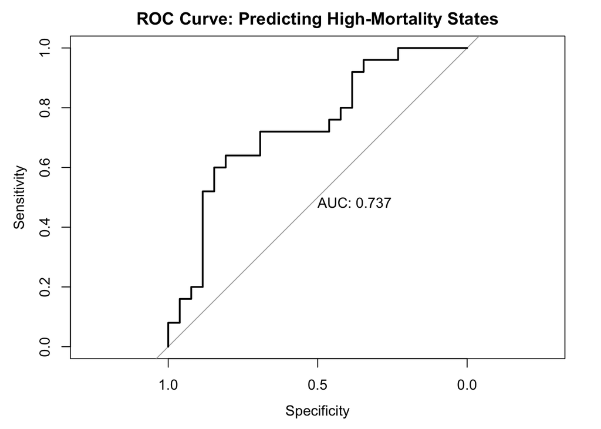

```r
# Predicted probabilities and ROC curve
state_clean$pred_prob <- predict(logit_fit, type = "response")

roc_obj <- roc(state_clean$high_mortality, state_clean$pred_prob)
plot.roc(roc_obj,
         main = "ROC Curve: Predicting High-Mortality States",
         print.auc = TRUE)
```

**Explaination:**

The ROC curve above evaluates how well the logistic regression model distinguishes high-mortality states from low-mortality states using three predictors:

- Vaccination coverage
- Testing intensity
- Government stringency

The curve plots Sensitivity (True Positive Rate) against 1 − Specificity (False Positive Rate) across all classification thresholds.

## 8. Clustering States by Pandemic Characteristics

```r
# K-means clustering and descriptive labels
scaled_features <- scale(
  state_clean %>%
    select(deaths_per_100k, vax_coverage, tests_per_1k, mean_stringency)
)

set.seed(123)
km <- kmeans(scaled_features, centers = 3)

state_clean <- state_clean %>%
  mutate(
    cluster = km$cluster,  # create cluster first (numeric)

    cluster_desc = case_when(
      cluster == 3 ~ "High vaccination, low mortality",
      cluster == 2 ~ "Low vaccination, high mortality",
      cluster == 1 ~ "High vaccination, moderate mortality",
      TRUE         ~ "Other"
    ),
    cluster_desc = factor(
      cluster_desc,
      levels = c(
        "Low vaccination, high mortality",
        "High vaccination, moderate mortality",
        "High vaccination, low mortality"
      )
    )
  )
```

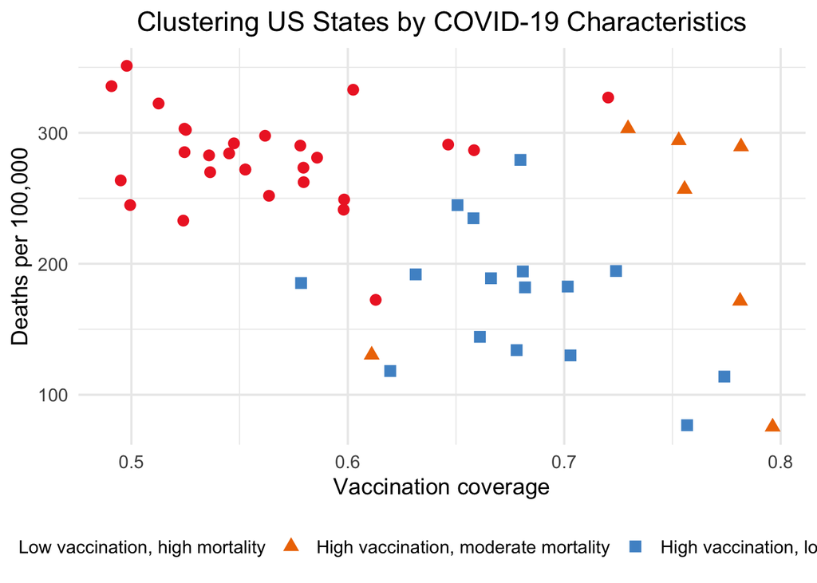

```r
ggplot(
  state_clean,
  aes(x = vax_coverage, y = deaths_per_100k,
      color = cluster_desc, shape = cluster_desc)
) +
  geom_point(size = 3) +
  labs(
    title = "Clustering US States by COVID-19 Characteristics",
    x = "Vaccination coverage",
    y = "Deaths per 100,000",
    color = "State cluster",
    shape = "State cluster"
  ) +
  scale_color_manual(values = c(
    "Low vaccination, high mortality"        = "firebrick2",
    "High vaccination, moderate mortality"   = "darkorange2",
    "High vaccination, low mortality"        = "steelblue3"
  )) +
  theme_minimal(base_size = 14) +
  theme(
    legend.position = "bottom",
    legend.title = element_blank()
  ) +
  theme(plot.title = element_text(hjust = 0.5))
```

**Interpretation:**

Together, the clusters tell a coherent epidemiological story:

- Low vaccination + high mortality cluster (red) → under-vaccination remains the strongest indicator of severe outcomes.
- High vaccination + low mortality cluster (blue) → vaccination is associated with substantially lower death rates.
- High vaccination + moderate mortality cluster (orange) → vaccination helps, but outcomes can still vary depending on contextual factors.

The separation between clusters shows that multivariate patterns of vaccination, deaths, and state-level characteristics naturally form meaningful groups, reinforcing the regression findings and providing a powerful visual summary of pandemic heterogeneity across the United States.

## 9. Spatial Visualization: US Choropleth Map

```r
# Quick view of state names used in state_clean
sort(unique(state_clean$state))[1:10]
```

```
##  [1] "Alabama"              "Alaska"               "Arizona"
##  [4] "Arkansas"             "California"           "Colorado"
##  [7] "Connecticut"          "Delaware"             "District of Columbia"
## [10] "Florida"
```

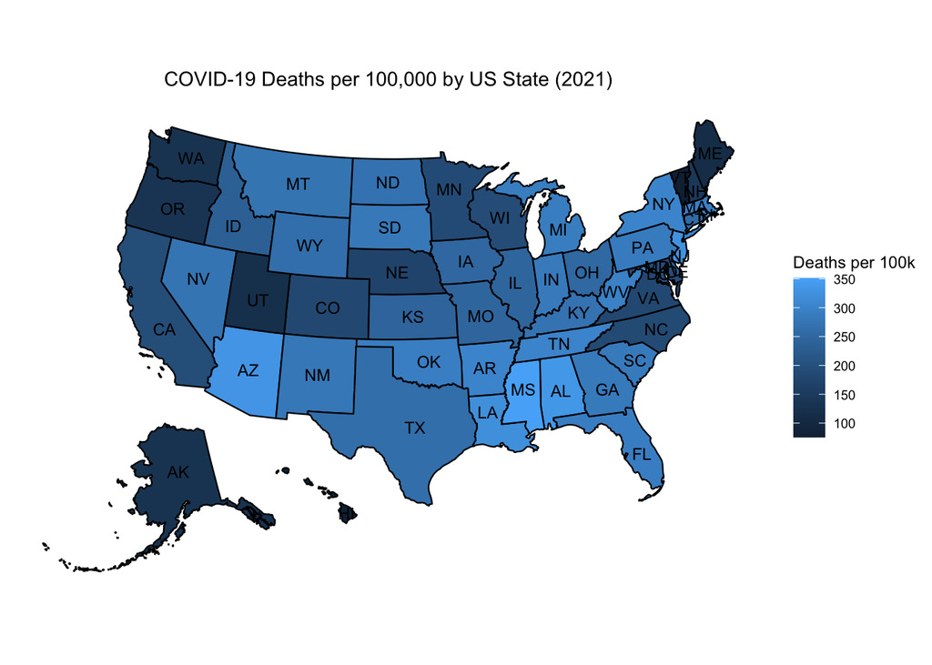

```r
library(usdata)

state_clean <- state_clean %>%
  mutate(state_abbrev = state2abbr(state))   # Converts full names → abbreviations

# Plot with labels
plot_usmap(data = state_clean, values = "deaths_per_100k", labels = TRUE) +
  scale_fill_continuous(
    name = "Deaths per 100k",
    label = scales::comma
  ) +
  labs(
    title = "COVID-19 Deaths per 100,000 by US State (2021)"
  ) +
  theme(legend.position = "right") +
  theme(plot.title = element_text(hjust = 0.5))
```

## 10. Random Forest and Variable Importance

```r
set.seed(123)

rf_fit <- randomForest(
  deaths_per_100k ~ vax_coverage + tests_per_1k + mean_stringency,
  data = state_clean,
  importance = TRUE,
  mtry = 2
)

rf_fit
```

```
##
## Call:
##  randomForest(formula = deaths_per_100k ~ vax_coverage + tests_per_1k +      mean_stringency, data = state_clean, importance = TRUE, mtry = 2)
##                Type of random forest: regression
##                      Number of trees: 500
## No. of variables tried at each split: 2
##
##           Mean of squared residuals: 5000.402
##                     % Var explained: -3.36
```

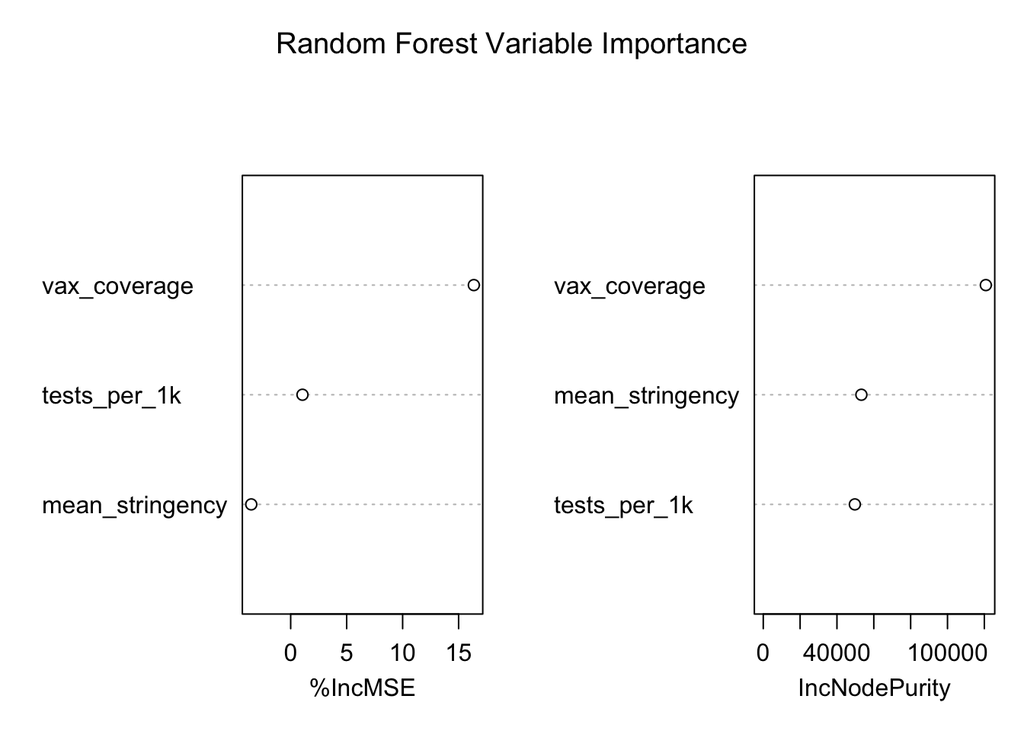

```r
# Variable importance plot
varImpPlot(rf_fit, main = "Random Forest Variable Importance")
```

## 11. Temporal Context: National Death Trends

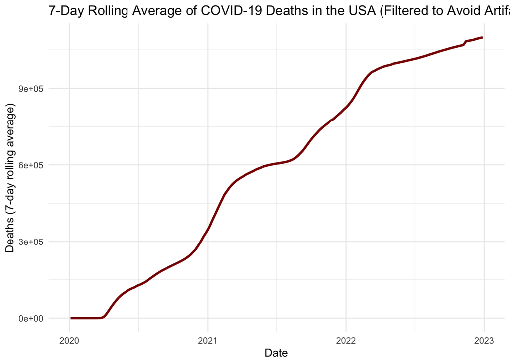

```r
usa_ts <- raw_df %>%
  clean_names() %>%
  filter(
    administrative_area_level_1 == "United States",
    date <= as.Date("2022-12-31")   # <-- FIX
  ) %>%
  group_by(date) %>%
  summarise(
    deaths = sum(deaths, na.rm = TRUE)
  ) %>%
  mutate(
    deaths_7day = zoo::rollmean(deaths, 7, fill = NA)
  )

ggplot(usa_ts, aes(date, deaths_7day)) +
  geom_line(color = "darkred", size = 1.1) +
  labs(
    title = "7-Day Rolling Average of COVID-19 Deaths in the USA (Filtered to Avoid Artifact)",
    x = "Date",
    y = "Deaths (7-day rolling average)"
  ) +
  theme_minimal()
```

**Interpretation:**

The figure shows the 7-day rolling average of cumulative COVID-19 deaths in the United States from early 2020 through the end of 2022. The smoothed curve highlights the major phases of the pandemic: an initial rise in mortality in mid-2020, a sharp acceleration during late 2020 and early 2021, and additional increases associated with subsequent waves such as Delta and Omicron. The curve steadily increases through 2022, reflecting the continued accumulation of deaths even as vaccination campaigns expanded.

To avoid misleading artifacts, the dataset was filtered to exclude dates after December 2022—when state-level reporting in the COVID19 package stops and values default to zero. Without this filtering, the sudden drop to zero produces an artificial vertical cliff in early 2023. Restricting the plot to valid reporting dates ensures an accurate representation of national mortality trends.